# Final Project: Adrian Harris & Christ Rangkas

```r
library(randomForest)
library(dplyr)
library(caret)
```

```r
library(ggplot2)
library(rpart)
library(e1071)
```

# Overview

We want to classify the data into different groups. Random Forest; We predicted the generation based on the other attributes. We then removed the some attrubutes in order to run the model.

# Pre-Processing

Cleaning the data and getting rid of atttributes that contain more that 53 catoregies. Both steps are important for categorizing data for random forests algothrim in R. Except country because we still have to filter thorugh it.

# Omitting the Null Values

```r
suicide <- read.csv("~/Desktop/master 7.csv", header=TRUE)
suicide = na.omit(suicide)
str(suicide)
```

```
## 'data.frame':    8364 obs. of  12 variables:
##  $ country           : Factor w/ 101 levels "Albania","Antigua and Barbuda",..: 1 1 1 1 1 1 1 1 1 1 ...
##  $ year              : int  1995 1995 1995 1995 1995 1995 1995 1995 1995 1995 ...
##  $ sex               : Factor w/ 2 levels "female","male": 2 2 1 1 2 2 2 1 1 2 ...
##  $ age               : Factor w/ 6 levels "15-24 years",..: 2 5 6 1 1 6 3 2 3 4 ...
##  $ suicides_no       : int  13 9 2 13 11 1 14 7 8 6 ...
##  $ population        : int  232900 178000 40800 283500 241200 25100 375900 264000 356400 376500 ...
##  $ suicides.100k.pop : num  5.58 5.06 4.9 4.59 4.56 3.98 3.72 2.65 2.24 1.59 ...
##  $ country.year      : Factor w/ 2321 levels "Albania1987",..: 7 7 7 7 7 7 7 7 7 7 ...
##  $ HDI.for.year      : num  0.619 0.619 0.619 0.619 0.619 0.619 0.619 0.619 0.619 0.619 ...
##  $ gdp_for_year....  : Factor w/ 2321 levels "1,002,219,052,968",..: 761 761 761 761 761 761 761 761 761 761 ...
##  $ gdp_per_capita....: int  835 835 835 835 835 835 835 835 835 835 ...
##  $ generation        : Factor w/ 6 levels "Boomers","G.I. Generation",..: 3 6 2 3 3 2 1 3 1 5 ...
##  - attr(*, "na.action")= 'omit' Named int  1 2 3 4 5 6 7 8 9 10 ...
##   ..- attr(*, "names")= chr  "1" "2" "3" "4" ...
```

# Getting rid of Attributes with more than 53 Categories

```r
newsuicide = suicide[,-c(8,10)]
str(newsuicide)
```

```
## 'data.frame':    8364 obs. of  10 variables:
##  $ country           : Factor w/ 101 levels "Albania","Antigua and Barbuda",..: 1 1 1 1 1 1 1 1 1 1 ...
##  $ year              : int  1995 1995 1995 1995 1995 1995 1995 1995 1995 1995 ...
##  $ sex               : Factor w/ 2 levels "female","male": 2 2 1 1 2 2 2 1 1 2 ...
##  $ age               : Factor w/ 6 levels "15-24 years",..: 2 5 6 1 1 6 3 2 3 4 ...
##  $ suicides_no       : int  13 9 2 13 11 1 14 7 8 6 ...
##  $ population        : int  232900 178000 40800 283500 241200 25100 375900 264000 356400 376500 ...
##  $ suicides.100k.pop : num  5.58 5.06 4.9 4.59 4.56 3.98 3.72 2.65 2.24 1.59 ...
##  $ HDI.for.year      : num  0.619 0.619 0.619 0.619 0.619 0.619 0.619 0.619 0.619 0.619 ...
##  $ gdp_per_capita....: int  835 835 835 835 835 835 835 835 835 835 ...
##  $ generation        : Factor w/ 6 levels "Boomers","G.I. Generation",..: 3 6 2 3 3 2 1 3 1 5 ...
```

# America Data Set

We decided to subset the data only to have American records.

```r
usa = newsuicide %>% filter(country == "United States")
str(usa)
```

```
## 'data.frame':    120 obs. of  10 variables:
##  $ country           : Factor w/ 101 levels "Albania","Antigua and Barbuda",..: 99 99 99 99 99 99 99 99 99 99 ...
##  $ year              : int  1985 1985 1985 1985 1985 1985 1985 1985 1985 1985 ...
##  $ sex               : Factor w/ 2 levels "female","male": 2 2 2 2 2 1 1 1 1 1 ...
##  $ age               : Factor w/ 6 levels "15-24 years",..: 6 5 2 3 1 3 5 6 2 1 ...
##  $ suicides_no       : int  2177 5302 5134 6053 4267 2105 1568 466 1242 854 ...
##  $ population        : int  4064000 17971000 20986000 26589000 19962000 27763000 21366000 7469000 21041000 19589000 ...
##  $ suicides.100k.pop : num  53.6 29.5 24.5 22.8 21.4 ...
##  $ HDI.for.year      : num  0.841 0.841 0.841 0.841 0.841 0.841 0.841 0.841 0.841 0.841 ...
##  $ gdp_per_capita....: int  19693 19693 19693 19693 19693 19693 19693 19693 19693 19693 ...
##  $ generation        : Factor w/ 6 levels "Boomers","G.I. Generation",..: 2 2 1 6 3 6 2 2 1 3 ...
```

# Removing the country variable beccause we know its the USA

```r
finalusa = usa[,-c(1)]
str(finalusa)
```

```
## 'data.frame':    120 obs. of  9 variables:
##  $ year              : int  1985 1985 1985 1985 1985 1985 1985 1985 1985 1985 ...
##  $ sex               : Factor w/ 2 levels "female","male": 2 2 2 2 2 1 1 1 1 1 ...
##  $ age               : Factor w/ 6 levels "15-24 years",..: 6 5 2 3 1 3 5 6 2 1 ...
##  $ suicides_no       : int  2177 5302 5134 6053 4267 2105 1568 466 1242 854 ...
##  $ population        : int  4064000 17971000 20986000 26589000 19962000 27763000 21366000 7469000 21041000 19589000 ...
##  $ suicides.100k.pop : num  53.6 29.5 24.5 22.8 21.4 ...
##  $ HDI.for.year      : num  0.841 0.841 0.841 0.841 0.841 0.841 0.841 0.841 0.841 0.841 ...
##  $ gdp_per_capita....: int  19693 19693 19693 19693 19693 19693 19693 19693 19693 19693 ...
##  $ generation        : Factor w/ 6 levels "Boomers","G.I. Generation",..: 2 2 1 6 3 6 2 2 1 3 ...
```

# Data Seperation

## Training and Testing Set

```r
set.seed(300)
sample = sample(2, nrow(finalusa), replace = T, prob = c(.7,.3))
train = finalusa[sample ==1,]
test = finalusa[sample ==2,]
```

# Random Forest

Before we didn’t have the mtry and importance.

```r
set.seed(300)
model1 = randomForest(generation~., data = train, mtry = 2, importance = T)
print(model1)
```

```
##
## Call:
##  randomForest(formula = generation ~ ., data = train, mtry = 2,      importance = T)
##                Type of random forest: classification
##                      Number of trees: 500
## No. of variables tried at each split: 2
##
##         OOB estimate of  error rate: 17.5%
## Confusion matrix:
##                 Boomers G.I. Generation Generation X Generation Z
## Boomers               5               0            3            0
## G.I. Generation       0               6            0            0
## Generation X          0               0           19            0
## Generation Z          0               0            0            7
## Millenials            0               0            1            0
## Silent                3               1            0            0
##                 Millenials Silent class.error
## Boomers                  0      2  0.50000000
## G.I. Generation          0      2  0.25000000
## Generation X             2      0  0.09523810
## Generation Z             0      0  0.00000000
## Millenials              17      0  0.05555556
## Silent                   0     12  0.25000000
```

# Prediction

With this prediction on the training data, it shows no error because this model was already run on this data senstivity.

```r
p1 = predict(model1, train)
confusionMatrix(p1, train$generation)
```

```
## Confusion Matrix and Statistics
##
##                  Reference
## Prediction        Boomers G.I. Generation Generation X Generation Z
##   Boomers              10               0            0            0
##   G.I. Generation       0               8            0            0
##   Generation X          0               0           21            0
##   Generation Z          0               0            0            7
##   Millenials            0               0            0            0
##   Silent                0               0            0            0
##                  Reference
## Prediction        Millenials Silent
##   Boomers                  0      0
##   G.I. Generation          0      0
##   Generation X             0      0
##   Generation Z             0      0
##   Millenials              18      0
##   Silent                   0     16
##
## Overall Statistics
##
##                Accuracy : 1
##                  95% CI : (0.9549, 1)
##     No Information Rate : 0.2625
##     P-Value [Acc > NIR] : < 2.2e-16
##
##                   Kappa : 1
##
##  Mcnemar's Test P-Value : NA
##
## Statistics by Class:
##
##                      Class: Boomers Class: G.I. Generation
## Sensitivity                   1.000                    1.0
## Specificity                   1.000                    1.0
## Pos Pred Value                1.000                    1.0
## Neg Pred Value                1.000                    1.0
## Prevalence                    0.125                    0.1
## Detection Rate                0.125                    0.1
## Detection Prevalence          0.125                    0.1
## Balanced Accuracy             1.000                    1.0
##                      Class: Generation X Class: Generation Z
## Sensitivity                       1.0000              1.0000
## Specificity                       1.0000              1.0000
## Pos Pred Value                    1.0000              1.0000
## Neg Pred Value                    1.0000              1.0000
## Prevalence                        0.2625              0.0875
## Detection Rate                    0.2625              0.0875
## Detection Prevalence              0.2625              0.0875
## Balanced Accuracy                 1.0000              1.0000
##                      Class: Millenials Class: Silent
## Sensitivity                      1.000           1.0
## Specificity                      1.000           1.0
## Pos Pred Value                   1.000           1.0
## Neg Pred Value                   1.000           1.0
## Prevalence                       0.225           0.2
## Detection Rate                   0.225           0.2
## Detection Prevalence             0.225           0.2
## Balanced Accuracy                1.000           1.0
```

```r
p1
```

```
##               5               6               8               9
##    Generation X          Silent G.I. Generation         Boomers
##              12              14              15              18
##    Generation X G.I. Generation         Boomers G.I. Generation
##              19              20              22              23
##          Silent G.I. Generation    Generation X    Generation X
##              24              25              26              27
##    Generation X G.I. Generation    Generation X          Silent
##              29              30              31              34
##    Generation X         Boomers G.I. Generation    Generation X
##              35              36              37              39
##      Millenials      Millenials G.I. Generation          Silent
##              41              42              45              47
##    Generation X         Boomers G.I. Generation      Millenials
##              48              49              51              53
##      Millenials          Silent          Silent      Millenials
##              56              57              60              61
##    Generation X          Silent      Millenials          Silent
##              62              63              64              65
##    Generation X          Silent    Generation X      Millenials
##              66              67              68              71
##    Generation X          Silent    Generation X    Generation Z
##              73              74              75              76
##          Silent    Generation X         Boomers      Millenials
##              77              79              80              82
##      Millenials         Boomers      Millenials          Silent
##              83              85              86              87
##    Generation Z          Silent    Generation X         Boomers
##              88              90              92              94
##      Millenials    Generation X      Millenials          Silent
##              96              97              98              99
##    Generation Z          Silent         Boomers    Generation X
##             100             102             105             107
##      Millenials    Generation X      Millenials    Generation Z
##             108             109             110             111
##    Generation Z          Silent         Boomers    Generation X
##             112             113             114             115
##      Millenials      Millenials    Generation X         Boomers
##             116             117             119             120
##      Millenials      Millenials    Generation Z    Generation Z
## 6 Levels: Boomers G.I. Generation Generation X ... Silent
```

# On Test Data

Our data hasn’t been seen by this random forest so the rate of error increases. We see that the model has difficulty predicting Boomers, Millenails and Silent.

```r
p2 = predict(model1, test)
confusionMatrix(p2, test$generation)
```

```
## Confusion Matrix and Statistics
##
##                  Reference
## Prediction        Boomers G.I. Generation Generation X Generation Z
##   Boomers               5               0            0            0
##   G.I. Generation       0               4            0            0
##   Generation X          3               0            9            0
##   Generation Z          0               0            0            3
##   Millenials            0               0            0            0
##   Silent                0               0            0            0
##                  Reference
## Prediction        Millenials Silent
##   Boomers                  0      0
##   G.I. Generation          0      2
##   Generation X             1      0
##   Generation Z             0      0
##   Millenials               7      0
##   Silent                   0      6
##
## Overall Statistics
##
##                Accuracy : 0.85
##                  95% CI : (0.7016, 0.9429)
##     No Information Rate : 0.225
##     P-Value [Acc > NIR] : < 2.2e-16
##
##                   Kappa : 0.8162
##
##  Mcnemar's Test P-Value : NA
##
## Statistics by Class:
##
##                      Class: Boomers Class: G.I. Generation
## Sensitivity                  0.6250                 1.0000
## Specificity                  1.0000                 0.9444
## Pos Pred Value               1.0000                 0.6667
## Neg Pred Value               0.9143                 1.0000
## Prevalence                   0.2000                 0.1000
## Detection Rate               0.1250                 0.1000
## Detection Prevalence         0.1250                 0.1500
## Balanced Accuracy            0.8125                 0.9722
##                      Class: Generation X Class: Generation Z
## Sensitivity                       1.0000               1.000
## Specificity                       0.8710               1.000
## Pos Pred Value                    0.6923               1.000
## Neg Pred Value                    1.0000               1.000
## Prevalence                        0.2250               0.075
## Detection Rate                    0.2250               0.075
## Detection Prevalence              0.3250               0.075
## Balanced Accuracy                 0.9355               1.000
##                      Class: Millenials Class: Silent
## Sensitivity                     0.8750        0.7500
## Specificity                     1.0000        1.0000
## Pos Pred Value                  1.0000        1.0000
## Neg Pred Value                  0.9697        0.9412
## Prevalence                      0.2000        0.2000
## Detection Rate                  0.1750        0.1500
## Detection Prevalence            0.1750        0.1500
## Balanced Accuracy               0.9375        0.8750
```

```r
p2
```

```
##               1               2               3               4
## G.I. Generation G.I. Generation         Boomers          Silent
##               7              10              11              13
## G.I. Generation    Generation X    Generation X G.I. Generation
##              16              17              21              28
##          Silent    Generation X         Boomers         Boomers
##              32              33              38              40
## G.I. Generation    Generation X    Generation X    Generation X
##              43              44              46              50
## G.I. Generation    Generation X    Generation X    Generation X
##              52              54              55              58
##    Generation X    Generation X          Silent    Generation X
##              59              69              70              72
##      Millenials      Millenials          Silent    Generation Z
##              78              81              84              89
##    Generation X      Millenials    Generation Z      Millenials
##              91              93              95             101
##         Boomers      Millenials    Generation Z      Millenials
##             103             104             106             118
##         Boomers      Millenials          Silent          Silent
## 6 Levels: Boomers G.I. Generation Generation X ... Silent
```

# Error

Error decreases to around 250 trees.

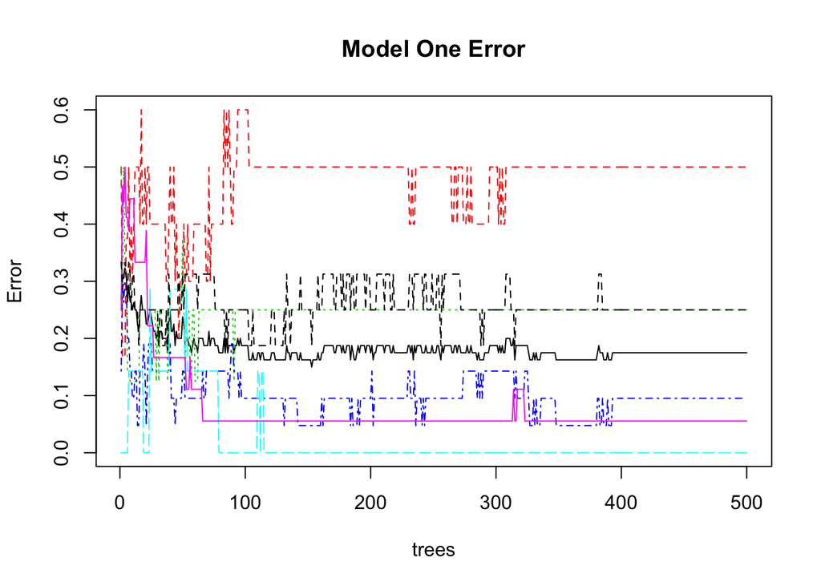

```r
plot(model1,
     main = "Model One Error")
```

# Tuning

## We will use all features, except for *Generation*, as predictors because we want to predict the response of the *Generation* feature.

Note: step ~ what we assign the mytry to be.

```
## mtry = 2  OOB error = 16.25%
## Searching left ...
## mtry = 4     OOB error = 17.5%
## -0.07692308 0.05
## Searching right ...
## mtry = 1     OOB error = 27.5%
## -0.6923077 0.05
```

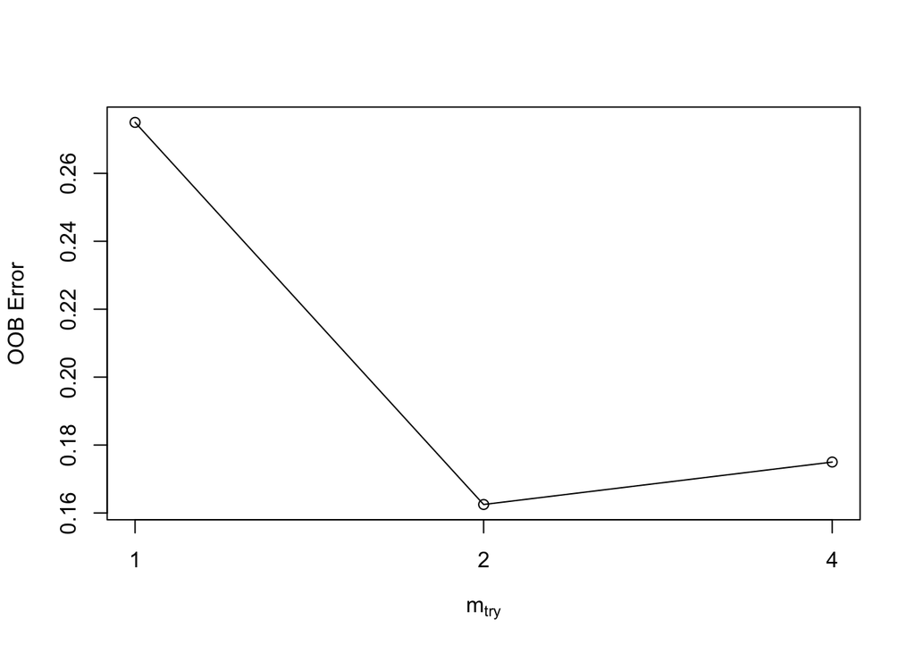

```r
t = tuneRF(train[,-9], train[,9],
       stepFactor = .5,
       plot = T,
       ntreeTry = 500,
       trace = T,
       improve = .05)
```

# Variance Plot

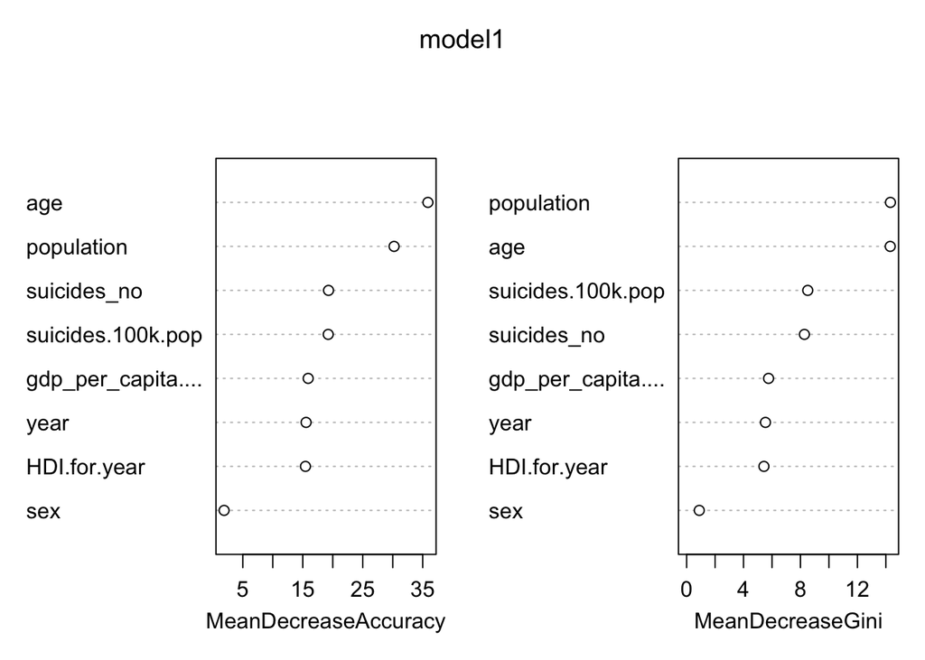

```r
varImpPlot(model1)
```

## *Quantity of Nodes*

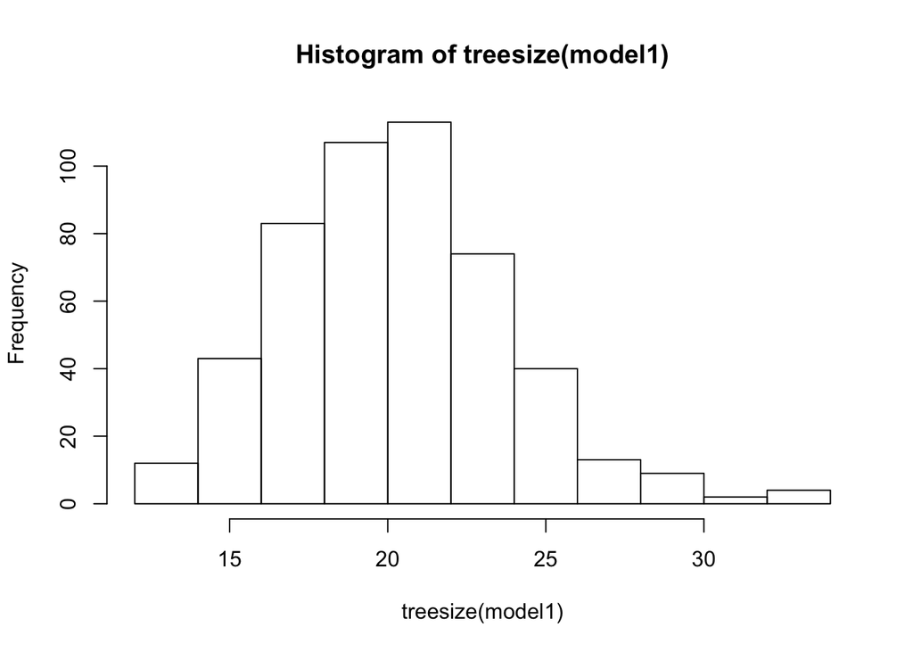

```r
hist(treesize(model1))
```

# Conclusion

# Overview

For clustering, we’re going to group countries into each “suicide category.” The clusters are unknown as of now, so it will be hierarchical complete linkage. From there, we will observe what group has the highest value present in each group.

```r
dis = dist(finalusa, method = "maximum")
```

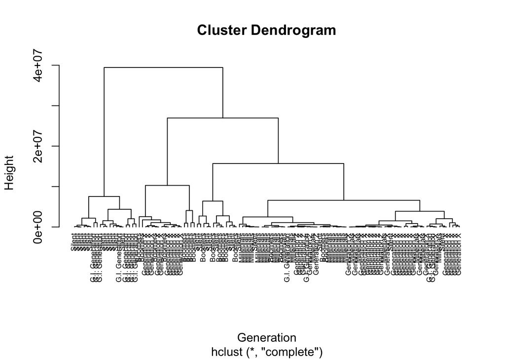

```r
hc1 = hclust(dis, method = "complete")
plot(hc1, cex = 0.6 , hang = -1, labels = finalusa$generation,
     xlab = "Generation")
```

The original had three, but then it broke it down to five.

```r
sub_grp = cutree(hc1, k = 5)
```

# Mutation

We included the clusters to the end of the data set for each observation.

```r
clustersss = finalusa %>% mutate(cluster = sub_grp)
```

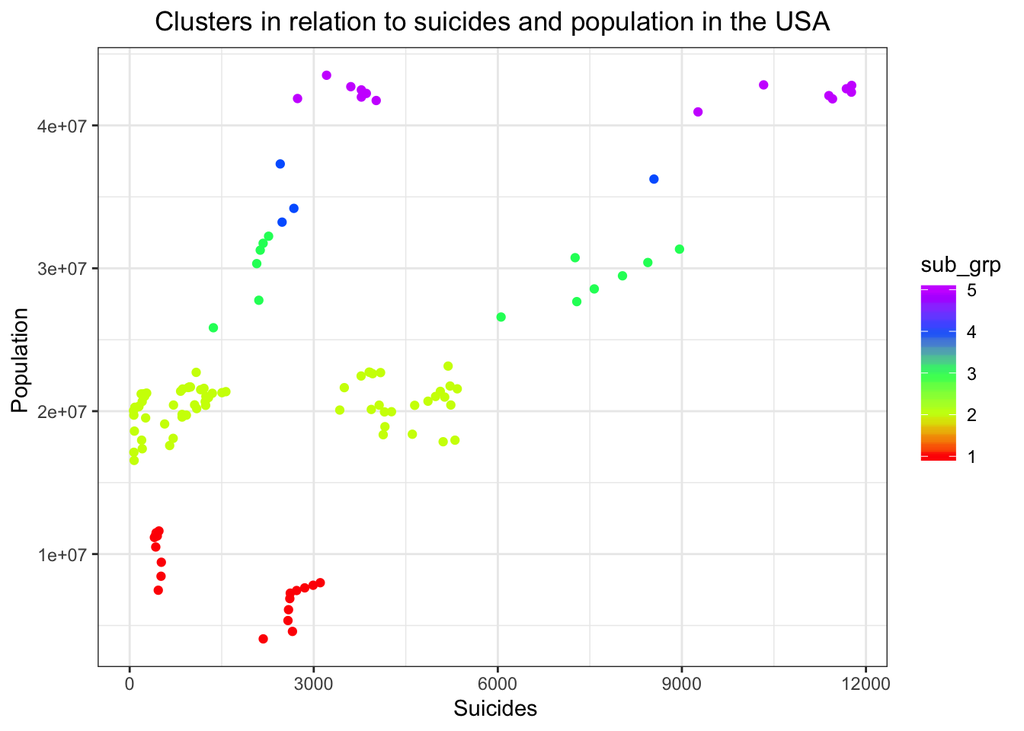

```r
ggplot(clustersss)+
  aes(x = finalusa$suicides_no,
      y = finalusa$population,
      color = sub_grp)+
      xlab(" Suicides")+
      ylab("Population ")+
      theme_bw()+
     ggtitle("Clusters in relation to suicides and population in the USA")+
     theme(plot.title = element_text(hjust = 0.5))+
     geom_point()+
  scale_color_gradientn(colours = rainbow(5))
```

## *Cluster One*

The Silent generation and the G.I. have lowest number of suicides. But after further investigation, they had more suicudes per 100k population.

```r
clusterone = clustersss %>% filter(sub_grp == "1")
table(clusterone$sex, clusterone$generation)
```

```
##
##          Boomers G.I. Generation Generation X Generation Z Millenials
##   female       0               4            0            0          0
##   male         0               4            0            0          0
##
##          Silent
##   female      6
##   male        6
```

## Mix of mostly Millennials and Generation X

```r
clustertwo = clustersss %>% filter(sub_grp == "2")
table(clustertwo$sex, clustertwo$generation)
```

```
##
##          Boomers G.I. Generation Generation X Generation Z Millenials
##   female       2               2           10            5         13
##   male         2               2           10            5         13
##
##          Silent
##   female      2
##   male        3
```

Looking into why the clusters are separated and what generations are on each side of the half way point I set. It is still a mixed set.

```r
clustersss %>% filter(sub_grp == "2" & suicides_no > 3000)
```

```
##    year  sex         age suicides_no population suicides.100k.pop
## 1  1985 male 55-74 years        5302   17971000             29.50
## 2  1985 male 25-34 years        5134   20986000             24.46
## 3  1985 male 15-24 years        4267   19962000             21.38
## 4  1990 male 55-74 years        5109   17861900             28.60
## 5  1990 male 25-34 years        5339   21564300             24.76
## 6  1990 male 15-24 years        4160   18915400             21.99
## 7  1995 male 25-34 years        5234   20432000             25.62
## 8  1995 male 55-74 years        4607   18386200             25.06
## 9  1995 male 15-24 years        4132   18352000             22.52
## 10 2000 male 55-74 years        4153   19948630             20.82
## 11 2000 male 25-34 years        3938   20120529             19.57
## 12 2000 male 15-24 years        3424   20078818             17.05
## 13 2005 male 55-74 years        5190   23156114             22.41
## 14 2005 male 25-34 years        4066   20421260             19.91
```

[output cut: 37 more lines]

```r
clustersss %>% filter(sub_grp == "2" & suicides_no < 3000)
```

```
##    year    sex         age suicides_no population suicides.100k.pop
## 1  1985 female 55-74 years        1568   21366000              7.34
## 2  1985 female 25-34 years        1242   21041000              5.90
## 3  1985 female 15-24 years         854   19589000              4.36
## 4  1985   male  5-14 years         205   17370000              1.18
## 5  1985 female  5-14 years          73   16553000              0.44
## 6  1990 female 55-74 years        1504   21296300              7.06
## 7  1990 female 25-34 years        1211   21596400              5.61
## 8  1990 female 15-24 years         709   18097900              3.92
## 9  1990   male  5-14 years         195   17970800              1.09
## 10 1990 female  5-14 years          69   17124400              0.40
## 11 1995 female 55-74 years        1157   21504100              5.38
## 12 1995 female 25-34 years        1058   20441200              5.18
## 13 1995 female 15-24 years         652   17594600              3.71
## 14 1995   male  5-14 years         260   19528500              1.33
```

[output cut: 75 more lines]

## *Cluter Three*

```r
clusterthree = clustersss %>% filter(sub_grp == "3")
table(clusterthree$sex, clusterthree$generation)
```

```
##
##          Boomers G.I. Generation Generation X Generation Z Millenials
##   female       2               0            0            0          0
##   male         4               0            0            0          0
##
##          Silent
##   female      4
##   male        3
```

Looking into why the clusters are separated and what generations are on each side of the half way point I set. It is still a mixed set between boomers and silent generation

```r
clustersss %>% filter(sub_grp == "3" & suicides_no < 6000)
```

```
##   year    sex         age suicides_no population suicides.100k.pop
## 1 1985 female 35-54 years        2105   27763000              7.58
## 2 1990 female 35-54 years        2175   31749500              6.85
## 3 2005 female 55-74 years        1364   25839240              5.28
## 4 2010 female 55-74 years        2071   30326595              6.83
## 5 2011 female 55-74 years        2128   31268702              6.81
## 6 2012 female 55-74 years        2264   32244829              7.02
##   HDI.for.year gdp_per_capita.... generation cluster
## 1        0.841              19693     Silent       3
## 2        0.859              26004     Silent       3
## 3        0.897              47423     Silent       3
## 4        0.909              51989     Silent       3
## 5        0.911              53452    Boomers       3
## 6        0.912              55170    Boomers       3
```

```r
clustersss %>% filter(sub_grp == "3" & suicides_no > 6000)
```

```
##   year  sex         age suicides_no population suicides.100k.pop
## 1 1985 male 35-54 years        6053   26589000             22.77
## 2 1990 male 35-54 years        7260   30742000             23.62
## 3 2010 male 55-74 years        7287   27667895             26.34
## 4 2011 male 55-74 years        7572   28556351             26.52
## 5 2012 male 55-74 years        8032   29473157             27.25
## 6 2013 male 55-74 years        8445   30405404             27.77
## 7 2014 male 55-74 years        8961   31339875             28.59
##   HDI.for.year gdp_per_capita.... generation cluster
## 1        0.841              19693     Silent       3
## 2        0.859              26004     Silent       3
## 3        0.909              51989     Silent       3
## 4        0.911              53452    Boomers       3
## 5        0.912              55170    Boomers       3
## 6        0.913              56520    Boomers       3
## 7        0.915              58531    Boomers       3
```

## *Cluster Four*

Boomers have higher popuation than cluster three, but lower on average when it comes to suicide.

```r
clusterfour = clustersss %>% filter(sub_grp == "4")
table(clusterfour$sex, clusterfour$generation)
```

```
##
##          Boomers G.I. Generation Generation X Generation Z Millenials
##   female       3               0            0            0          0
##   male         1               0            0            0          0
##
##          Silent
##   female      0
##   male        0
```

## *Cluster Five*

Boomers and Generation X have the most suciide because of higher population and highest HDI.

```r
clusterfive = clustersss %>% filter(sub_grp == "5")
table(clusterfive$sex, clusterfive$generation)
```

```
##
##          Boomers G.I. Generation Generation X Generation Z Millenials
##   female       2               0            5            0          0
##   male         2               0            5            0          0
##
##          Silent
##   female      0
##   male        0
```

This cluster is being tied together through population GenX is accounting for most of the suicides in the group

```r
highsui = clustersss %>% filter(sub_grp == "5" & suicides_no > 6000)
```

```r
highsui = clustersss %>% filter(sub_grp == "5" & suicides_no < 6000)
```

## *Cluster Attributes*

```r
clusteratr = clustersss %>% group_by(cluster) %>%
  summarize(nosui= mean(suicides_no),
            pop = mean(population),
            suic10 = mean(suicides.100k.pop),
            hdi = mean(HDI.for.year),
            gdpmean = mean(gdp_per_capita....))
clusteratr
```

```
## # A tibble: 5 x 6
##   cluster nosui       pop suic10   hdi gdpmean
##     <int> <dbl>     <dbl>  <dbl> <dbl>   <dbl>
## 1       1 1571.  8458057.  23.6  0.892  43952.
## 2       2 2029. 20437407.   9.85 0.889  42281.
## 3       3 5055. 29535811.  17.2  0.891  44238.
## 4       4 4040. 35242452.  11.4  0.895  44522.
## 5       5 7331. 42283377.  17.4  0.906  51758.
```

# Support Vector Machines

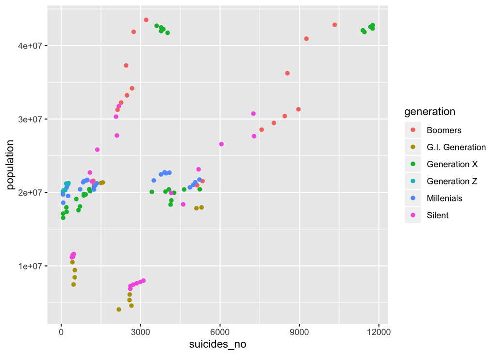

```r
qplot(suicides_no,population, data = finalusa, color = generation)
```

# Using Radial Kernel

There are a total of 115 Support Vectors; Boomers = 12 G.I. Generation = 18 Generation X = 22 Generation Z = 29 Millenials = 24 Silent = 10

```r
model = svm(generation~., data = finalusa, kernel = "radial")
summary(model)
```

```
##
## Call:
## svm(formula = generation ~ ., data = finalusa, kernel = "radial")
##
##
## Parameters:
##    SVM-Type:  C-classification
##  SVM-Kernel:  radial
##        cost:  1
##
## Number of Support Vectors:  115
##
##  ( 12 18 22 29 24 10 )
##
##
## Number of Classes:  6
##
## Levels:
##  Boomers G.I. Generation Generation X Generation Z Millenials Silent
```

# SVM Classification Plot

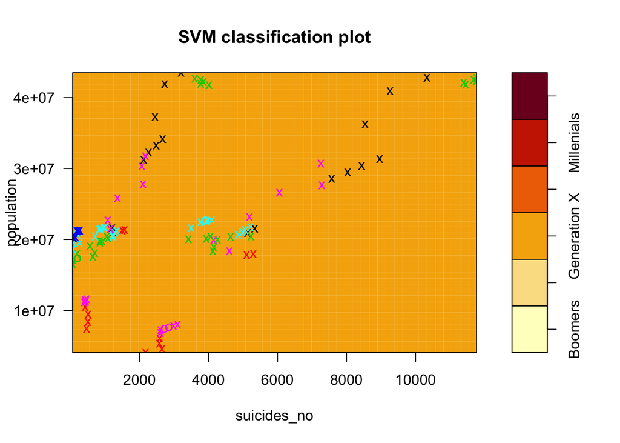

```r
plot(model, data = finalusa, population~suicides_no , slice = list(HDI.for.year = 1, suicides.100k.pop = 6))
```

# Prediction

```r
prediction = predict(model, finalusa)
prediction
```

```
##               1               2               3               4
## G.I. Generation G.I. Generation    Generation X          Silent
##               5               6               7               8
##    Generation X    Generation X    Generation X G.I. Generation
##               9              10              11              12
##    Generation X    Generation X    Generation X    Generation X
##              13              14              15              16
## G.I. Generation    Generation X    Generation X          Silent
##              17              18              19              20
##    Generation X    Generation X         Boomers G.I. Generation
##              21              22              23              24
##    Generation X    Generation X    Generation X    Generation X
##              25              26              27              28
## G.I. Generation    Generation X          Silent         Boomers
##              29              30              31              32
##    Generation X         Boomers G.I. Generation          Silent
##              33              34              35              36
##    Generation X    Generation X    Generation X    Generation X
##              37              38              39              40
## G.I. Generation         Boomers          Silent    Generation X
##              41              42              43              44
##    Generation X         Boomers          Silent    Generation X
##              45              46              47              48
##          Silent    Generation X      Millenials      Millenials
##              49              50              51              52
##          Silent    Generation X          Silent      Millenials
##              53              54              55              56
##      Millenials    Generation X          Silent      Millenials
##              57              58              59              60
##          Silent      Millenials    Generation Z      Millenials
##              61              62              63              64
##          Silent    Generation X         Boomers      Millenials
##              65              66              67              68
##      Millenials    Generation X         Boomers      Millenials
##              69              70              71              72
##      Millenials          Silent    Generation Z    Generation Z
##              73              74              75              76
##          Silent    Generation X         Boomers      Millenials
##              77              78              79              80
##      Millenials    Generation X         Boomers      Millenials
##              81              82              83              84
##      Millenials          Silent    Generation Z    Generation Z
##              85              86              87              88
##          Silent    Generation X         Boomers      Millenials
##              89              90              91              92
##      Millenials    Generation X         Boomers      Millenials
##              93              94              95              96
##      Millenials          Silent    Generation Z    Generation Z
##              97              98              99             100
##          Silent         Boomers    Generation X      Millenials
##             101             102             103             104
##      Millenials    Generation X         Boomers      Millenials
##             105             106             107             108
##      Millenials          Silent    Generation Z    Generation Z
##             109             110             111             112
##          Silent         Boomers    Generation X      Millenials
##             113             114             115             116
##      Millenials    Generation X         Boomers      Millenials
##             117             118             119             120
##      Millenials          Silent    Generation Z    Generation Z
## 6 Levels: Boomers G.I. Generation Generation X ... Silent
```

```r
t = table(Predicted = prediction, Actual = finalusa$generation)
t
```

```
##                  Actual
## Predicted         Boomers G.I. Generation Generation X Generation Z
##   Boomers              12               0            0            0
##   G.I. Generation       0               8            0            0
##   Generation X          6               3           26            0
##   Generation Z          0               0            0           10
##   Millenials            0               0            4            0
##   Silent                0               1            0            0
##                  Actual
## Predicted         Millenials Silent
##   Boomers                  0      3
##   G.I. Generation          0      0
##   Generation X             2      1
##   Generation Z             1      0
##   Millenials              23      0
##   Silent                   0     20
```

# The Model Misclassified by about 17.5% *Ouch*

```r
1-sum(diag(t))/sum(t)
```

```
## [1] 0.175
```

# Using Linear Kernel

There are a total of 91 Support Vectors Boomers = 6 G.I. Generation = 16 Generation X = 18 Generation Z = 28 Millenials = 18 Silent = 5

```r
lmodel = svm(generation~., data = finalusa, kernel = "linear")
summary(lmodel)
```

```
##
## Call:
## svm(formula = generation ~ ., data = finalusa, kernel = "linear")
##
##
## Parameters:
##    SVM-Type:  C-classification
##  SVM-Kernel:  linear
##        cost:  1
##
## Number of Support Vectors:  91
##
##  ( 6 16 18 28 18 5 )
##
##
## Number of Classes:  6
##
## Levels:
##  Boomers G.I. Generation Generation X Generation Z Millenials Silent
```

# SVM Classification Plot

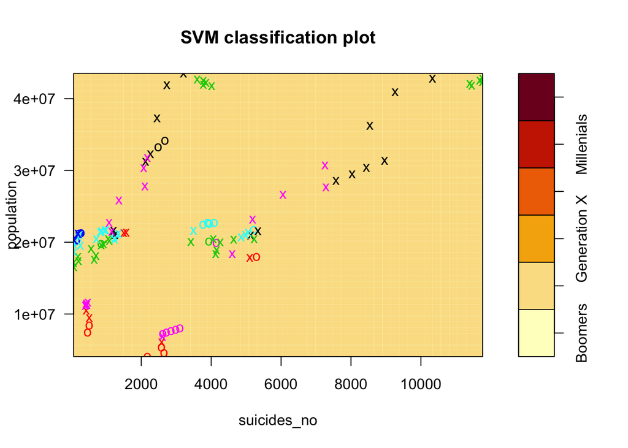

```r
plot(lmodel, data = finalusa, population~suicides_no , slice = list(HDI.for.year = 1, suicides.100k.pop = 6))
```

# Prediction

```r
lprediction = predict(lmodel, finalusa)
lprediction
```

```
##               1               2               3               4
## G.I. Generation G.I. Generation         Boomers         Boomers
##               5               6               7               8
## G.I. Generation         Boomers G.I. Generation G.I. Generation
##               9              10              11              12
##         Boomers G.I. Generation    Generation X    Generation X
##              13              14              15              16
## G.I. Generation G.I. Generation         Boomers         Boomers
##              17              18              19              20
##    Generation X G.I. Generation         Boomers G.I. Generation
##              21              22              23              24
##         Boomers    Generation X    Generation X    Generation X
##              25              26              27              28
## G.I. Generation    Generation X          Silent         Boomers
##              29              30              31              32
##    Generation X         Boomers G.I. Generation          Silent
##              33              34              35              36
##    Generation X    Generation X      Millenials      Millenials
##              37              38              39              40
## G.I. Generation         Boomers          Silent    Generation X
##              41              42              43              44
##    Generation X         Boomers          Silent    Generation X
##              45              46              47              48
## G.I. Generation    Generation X      Millenials      Millenials
##              49              50              51              52
##          Silent         Boomers          Silent    Generation X
##              53              54              55              56
##      Millenials         Boomers          Silent    Generation X
##              57              58              59              60
##          Silent      Millenials    Generation Z      Millenials
##              61              62              63              64
##          Silent    Generation X         Boomers      Millenials
##              65              66              67              68
##      Millenials    Generation X         Boomers      Millenials
##              69              70              71              72
##      Millenials          Silent    Generation Z    Generation Z
##              73              74              75              76
##          Silent    Generation X         Boomers      Millenials
##              77              78              79              80
##      Millenials    Generation X         Boomers      Millenials
##              81              82              83              84
##      Millenials          Silent    Generation Z    Generation Z
##              85              86              87              88
##          Silent    Generation X         Boomers      Millenials
##              89              90              91              92
##      Millenials    Generation X         Boomers      Millenials
##              93              94              95              96
##      Millenials          Silent    Generation Z    Generation Z
##              97              98              99             100
##          Silent         Boomers    Generation X      Millenials
##             101             102             103             104
##      Millenials    Generation X         Boomers      Millenials
##             105             106             107             108
##      Millenials          Silent    Generation Z    Generation Z
##             109             110             111             112
##          Silent         Boomers    Generation X      Millenials
##             113             114             115             116
##      Millenials    Generation X         Boomers      Millenials
##             117             118             119             120
##      Millenials          Silent    Generation Z    Generation Z
## 6 Levels: Boomers G.I. Generation Generation X ... Silent
```

```r
lt = table(Predicted = lprediction, Actual = finalusa$generation)
lt
```

```
##                  Actual
## Predicted         Boomers G.I. Generation Generation X Generation Z
##   Boomers              18               0            0            0
##   G.I. Generation       0              12            2            0
##   Generation X          0               0           26            0
##   Generation Z          0               0            0           10
##   Millenials            0               0            2            0
##   Silent                0               0            0            0
##                  Actual
## Predicted         Millenials Silent
##   Boomers                  0      6
##   G.I. Generation          0      0
##   Generation X             0      0
##   Generation Z             1      0
##   Millenials              25      0
##   Silent                   0     18
```

# This Model Misclassed by about 9.17%

```r
1-sum(diag(lt))/sum(lt)
```

```
## [1] 0.09166667
```

# Using Polynomial Kernel

There are a total of 117 Support Vectors Boomers = 10 G.I. Generation = 18 Generation X = 24 Generation Z = 29 Millenials = 26 Silent = 10

```r
pmodel = svm(generation~., data = finalusa, kernel = "polynomial")
summary(pmodel)
```

```
##
## Call:
## svm(formula = generation ~ ., data = finalusa, kernel = "polynomial")
##
##
## Parameters:
##    SVM-Type:  C-classification
##  SVM-Kernel:  polynomial
##        cost:  1
##      degree:  3
##      coef.0:  0
##
## Number of Support Vectors:  117
##
##  ( 10 18 24 29 26 10 )
##
##
## Number of Classes:  6
##
## Levels:
##  Boomers G.I. Generation Generation X Generation Z Millenials Silent
```

# SVM Classification Plot

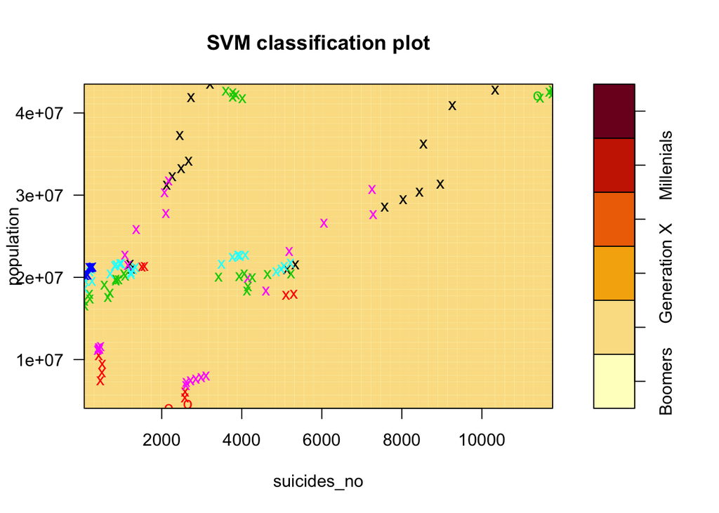

```r
plot(pmodel, data = finalusa, population~suicides_no , slice = list(HDI.for.year = 1, suicides.100k.pop = 6))
```

# Prediction

```r
pprediction = predict(pmodel, finalusa)
pprediction
```

```
##               1               2               3               4
## G.I. Generation G.I. Generation    Generation X          Silent
##               5               6               7               8
##    Generation X          Silent    Generation X G.I. Generation
##               9              10              11              12
##    Generation X    Generation X    Generation X    Generation X
##              13              14              15              16
## G.I. Generation    Generation X    Generation X          Silent
##              17              18              19              20
##      Millenials    Generation X          Silent G.I. Generation
##              21              22              23              24
##    Generation X    Generation X      Millenials    Generation X
##              25              26              27              28
## G.I. Generation      Millenials      Millenials         Boomers
##              29              30              31              32
##      Millenials      Millenials      Millenials      Millenials
##              33              34              35              36
##      Millenials      Millenials      Millenials      Millenials
##              37              38              39              40
##          Silent    Generation X      Millenials      Millenials
##              41              42              43              44
##      Millenials      Millenials      Millenials      Millenials
##              45              46              47              48
##      Millenials      Millenials      Millenials      Millenials
##              49              50              51              52
##          Silent    Generation X      Millenials      Millenials
##              53              54              55              56
##      Millenials    Generation X      Millenials      Millenials
##              57              58              59              60
##      Millenials      Millenials      Millenials      Millenials
##              61              62              63              64
##          Silent    Generation X      Millenials      Millenials
##              65              66              67              68
##      Millenials    Generation X      Millenials      Millenials
##              69              70              71              72
##      Millenials      Millenials      Millenials      Millenials
##              73              74              75              76
##          Silent    Generation X      Millenials      Millenials
##              77              78              79              80
##      Millenials    Generation X      Millenials      Millenials
##              81              82              83              84
##      Millenials      Millenials      Millenials      Millenials
##              85              86              87              88
##          Silent    Generation X         Boomers      Millenials
##              89              90              91              92
##      Millenials    Generation X      Millenials      Millenials
##              93              94              95              96
##      Millenials      Millenials      Millenials      Millenials
##              97              98              99             100
##          Silent         Boomers    Generation X      Millenials
##             101             102             103             104
##      Millenials    Generation X      Millenials      Millenials
##             105             106             107             108
##      Millenials      Millenials      Millenials      Millenials
##             109             110             111             112
##          Silent         Boomers    Generation X      Millenials
##             113             114             115             116
##      Millenials    Generation X      Millenials      Millenials
##             117             118             119             120
##      Millenials      Millenials      Millenials      Millenials
## 6 Levels: Boomers G.I. Generation Generation X ... Silent
```

```r
pt = table(Predicted = pprediction, Actual = finalusa$generation)
pt
```

```
##                  Actual
## Predicted         Boomers G.I. Generation Generation X Generation Z
##   Boomers               4               0            0            0
##   G.I. Generation       0               6            0            0
##   Generation X          7               3           16            0
##   Generation Z          0               0            0            0
##   Millenials            7               2           14           10
##   Silent                0               1            0            0
##                  Actual
## Predicted         Millenials Silent
##   Boomers                  0      0
##   G.I. Generation          0      0
##   Generation X             0      0
##   Generation Z             0      0
##   Millenials              26     14
##   Silent                   0     10
```

# This Model Misclassed by about 48.3% *Disgusting*

```r
1-sum(diag(pt))/sum(pt)
```

```
## [1] 0.4833333
```

# Log Regression

I started by using backwards selection and then just settled on using these predictors

```r
set.seed(300)
sample = sample(2, nrow(finalusa), replace = T, prob = c(.7,.3))
train = finalusa[sample ==1,]
test = finalusa[sample ==2,]
```

```r
logreg = glm(sex ~ train$suicides_no +
               train$generation +
               train$population , data = train, family = binomial)
```

Agian number of suicides and population are big predictors for this data set

```r
summary(logreg)
```

```
##
## Call:
## glm(formula = sex ~ train$suicides_no + train$generation + train$population,
##     family = binomial, data = train)
##
## Deviance Residuals:
##      Min        1Q    Median        3Q       Max
## -1.35308  -0.38073   0.00399   0.18078   2.31850
##
## Coefficients:
##                                   Estimate Std. Error z value Pr(>|z|)
## (Intercept)                      1.266e+00  5.798e+00   0.218  0.82714
## train$suicides_no                2.055e-03  5.671e-04   3.624  0.00029 ***
## train$generationG.I. Generation -1.935e+00  5.550e+00  -0.349  0.72741
## train$generationGeneration X     2.617e+00  5.185e+00   0.505  0.61379
## train$generationGeneration Z     6.496e+00  5.283e+00   1.230  0.21885
## train$generationMillenials       3.550e+00  5.154e+00   0.689  0.49099
## train$generationSilent          -1.714e-01  5.260e+00  -0.033  0.97400
## train$population                -3.771e-07  1.624e-07  -2.322  0.02024 *
## ---
## Signif. codes:  0 '***' 0.001 '**' 0.01 '*' 0.05 '.' 0.1 ' ' 1
##
## (Dispersion parameter for binomial family taken to be 1)
##
##     Null deviance: 110.453  on 79  degrees of freedom
## Residual deviance:  33.817  on 72  degrees of freedom
## AIC: 49.817
##
## Number of Fisher Scoring iterations: 7
```

```r
coef(logreg)
```

```
##                     (Intercept)               train$suicides_no
##                    1.266059e+00                    2.055305e-03
## train$generationG.I. Generation    train$generationGeneration X
##                   -1.934749e+00                    2.616790e+00
##    train$generationGeneration Z      train$generationMillenials
##                    6.495827e+00                    3.549834e+00
##          train$generationSilent                train$population
##                   -1.714282e-01                   -3.770599e-07
```

Low percent is to a female and high is for a male

```r
pro = predict(logreg, train,  type = "response")
```

```r
head(pro)
```

```
##           5           6           8           9          12          14
## 0.994094602 0.006385839 0.073974663 0.016064168 0.098982143 0.956762854
```

```r
head(train)
```

```
##    year    sex         age suicides_no population suicides.100k.pop
## 5  1985   male 15-24 years        4267   19962000             21.38
## 6  1985 female 35-54 years        2105   27763000              7.58
## 8  1985 female   75+ years         466    7469000              6.24
## 9  1985 female 25-34 years        1242   21041000              5.90
## 12 1985 female  5-14 years          73   16553000              0.44
## 14 1990   male 55-74 years        5109   17861900             28.60
##    HDI.for.year gdp_per_capita....      generation
## 5         0.841              19693    Generation X
## 6         0.841              19693          Silent
## 8         0.841              19693 G.I. Generation
## 9         0.841              19693         Boomers
## 12        0.841              19693    Generation X
## 14        0.859              26004 G.I. Generation
```

Dummy variable

```r
contrasts(train$sex)
```

```
##        male
## female    0
## male      1
```

Error

```r
predict1 = ifelse(pro>.5,1,0)
```

```r
table(predict1, train$sex)
```

```
##
## predict1 female male
##        0     34    3
##        1      3   40
```

The error is very minimal on training set

```r
6/80
```

```
## [1] 0.075
```

```r
logreg2 = glm(sex ~ test$suicides_no +
               test$generation +
               test$population , data = test, family = binomial)
```

Test

```r
pro2 = predict(logreg2, test,  type = "response")
predict2 = ifelse(pro2>.5,1,0)
```

Same error on the testing set

```r
table(predict2, test$sex)
```

```
##
## predict2 female male
##        0     23    3
##        1      0   14
```

```r
3/40
```

```
## [1] 0.075
```

Turning the Predictions into data set so they can be plotted

```r
trainpre = data.frame(predict1, prob1 = pro,
                  suicides = train$suicides_no,
                  gen = train$generation,
                  pop = train$population)
```

```r
testpre = data.frame(predict2, prob2 = pro2,
                     suicides = test$suicides_no,
                     gen = test$generation,
                     pop = test$population)
```

Train

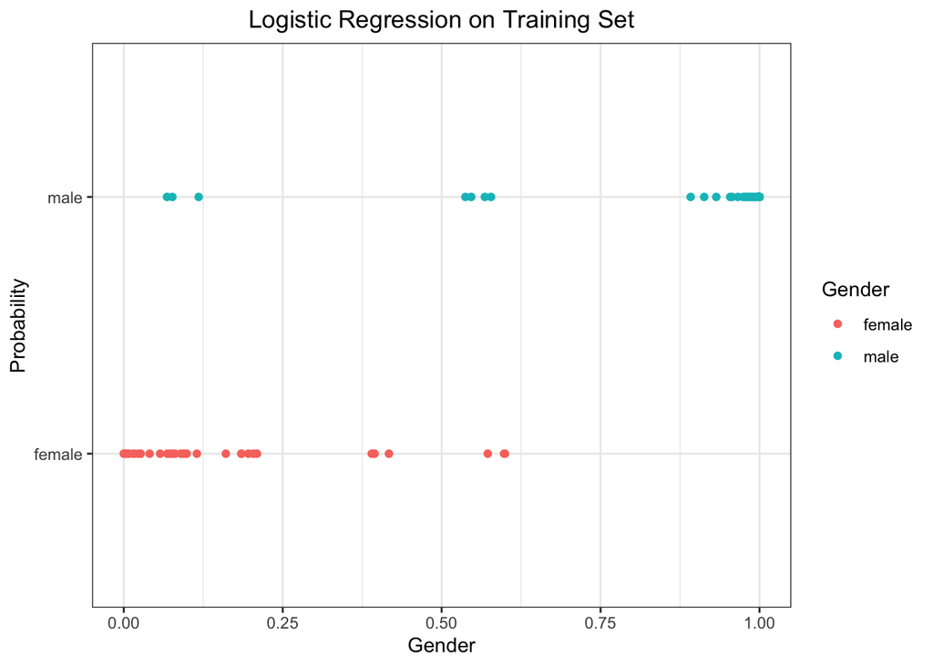

```r
ggplot(trainpre)+
  aes(x = prob1,
      y = train$sex,
      color = train$sex)+
  theme_bw()+
  xlab("Gender")+
  ylab("Probability")+
  scale_color_discrete(name = 'Gender')+
  ggtitle("Logistic Regression on Training Set")+
  theme(plot.title = element_text(hjust = 0.5))+
  geom_point()
```

Test

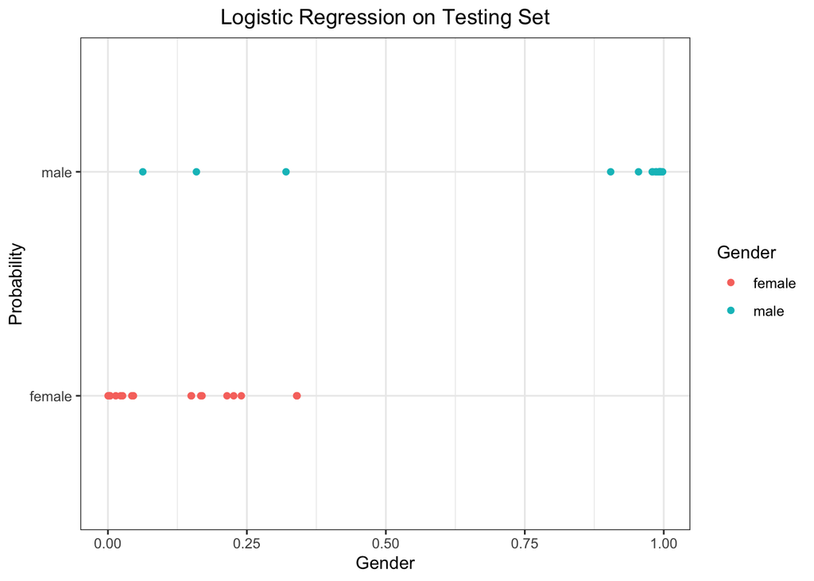

```r
ggplot(testpre)+
  aes(x = prob2,
      y = test$sex,
      color = test$sex)+
  xlab("Gender")+
  ylab("Probability")+
  scale_color_discrete(name = 'Gender')+
  ggtitle("Logistic Regression on Testing Set")+
  theme_bw()+
  theme(plot.title = element_text(hjust = 0.5))+
  geom_point()
```

# Conclusion

By performing clustering, random forest, and support vector machine techniques, we saw that boomers and the silents generation are closely related. On the other hand Gen X, Boomers, and Millenials share some relation. Genz is the most unique.

We thought we had made a mistake in our analysis because if they are close, they might be grouped together. But from looking at each cluster, specifically cluster two, that wasn’t the case.

# Road Blocks & Struggles

Our main struggles mainly were that we hoped we did not lose *value* in our dataset due to omitting null values. In addition, we aren’t to confident with our findings using svm techniques after looking at our classification plots. We may need to study more on this technique. Logistic Regression in R markdown wasn’t taking the table function for the test set. I had to run it a different a different model. When I did this in the script there were four miss classifications comapared to the three. This make little difference but could be fatal on larger data sets. This could of been solved if there was no partionting of the data set into training and test sets.

### Contribution

There was not alot of learning methods that were applied on this dataset.We want to get more out of this data set.

### References

https://www.kaggle.com/russellyates88/suicide-rates-overview-1985-to-2016

The Introduction to Statisical Learning